# ch1_comm_comp

Lia Domke

10/1/2020

In chapter 1, objective 2: 2) Determine if salmon are present in higher abundances in vegetated habitat compared to unvegetated habitat based on NOAA data from Prince of Wales (1998-2011).

Hypothesis two: H1: Salmon species composition (including all 5 Pacific salmon species) will differ between vegetated and unvegetated habitat, with vegetated sites having more similar composition of salmon species than unvegetated sites.

I’m interested in first, what the *overall* community composition (all species) is in the subset of habitats that we have identified in objective 2, hypothesis 2.

First we’re going to have to import the full noaa data set, and the subset of sites I’ve already identified.

1. Import datasets
2. Subset full dataset by the EventIDs already identified.
3. Data cleaning: create one dataset with species info another with environmental information
4. Data exploration

4.1 look into transformation and standardizing for seine

4.2 transformation and standardizing for environmental

5. NMDS works

5.1 Calculate dissimilarity index for both dataframes

5.2 Dispersion test

5.3 Calculate NMDS

4. Create species biplot
5. Overlay environmental parameters?
6. Clean up NMDS plots

# Import data

```r
noaa <- read.csv("../APECS Master repository/APECS Master repo/ALL_DATA/Lia_fish/noaa_seak_fish_atlas_CLEAN_LD.csv")

sal_env <- read.csv("Data/NOAA_SSEAK_salmon.csv", header = TRUE, stringsAsFactors = FALSE)
```

# Subset data

```
##  [1]  244  245  237  236 3188 3189 3191 3190 3171 3172 3170 3169 3173 3174 3168
## [16] 3186 3187 3178 3179 3176 3177 3181 3180  574  571  572  573 3175
```

```
##  [1] 133 134 132 131 615 616 618 617 598 599 597 596 600 601 595 613 614 605 606
## [20] 603 604 608 607 339 336 337 338 602
```

```
## Rows: 2,097
## Columns: 25
## $ X                 <int> 35735, 35737, 35738, 35739, 35740, 35741, 35742, 35…
## $ SiteID            <int> 133, 133, 133, 133, 133, 133, 133, 133, 133, 133, 1…
## $ EventID           <int> 244, 244, 244, 244, 244, 244, 244, 244, 244, 244, 2…
## $ Date              <chr> "5/12/98", "5/12/98", "5/12/98", "5/12/98", "5/12/9…
## $ Season            <chr> "Spring98", "Spring98", "Spring98", "Spring98", "Sp…
## $ Mon               <chr> "May", "May", "May", "May", "May", "May", "May", "M…
## $ SeasonNoYear      <chr> "Spring", "Spring", "Spring", "Spring", "Spring", "…
## $ Year              <int> 1998, 1998, 1998, 1998, 1998, 1998, 1998, 1998, 199…
## $ Gear              <chr> "BSEINE", "BSEINE", "BSEINE", "BSEINE", "BSEINE", "…
## $ Temp              <dbl> 9.9, 9.9, 9.9, 9.9, 9.9, 9.9, 9.9, 9.9, 9.9, 9.9, 9…
## $ Salinity          <dbl> 24, 24, 24, 24, 24, 24, 24, 24, 24, 24, 24, 24, 24,…
## $ Region            <chr> "southeastern Alaska", "southeastern Alaska", "sout…
## $ Locale            <chr> "Klawock Inlet", "Klawock Inlet", "Klawock Inlet", …
## $ Location          <chr> "Prince of Wales Island", "Prince of Wales Island",…
## $ SubLocale         <chr> "", "", "", "", "", "", "", "", "", "", "", "", "",…
## $ Nickname          <chr> "Craig Boat Ramp", "Craig Boat Ramp", "Craig Boat R…
## $ Habitat           <chr> "Sand-Gravel", "Sand-Gravel", "Sand-Gravel", "Sand-…
## $ Lat1              <dbl> 55.5619, 55.5619, 55.5619, 55.5619, 55.5619, 55.561…
## $ Long1             <dbl> -133.0997, -133.0997, -133.0997, -133.0997, -133.09…
## $ SpCode            <chr> "PERCHSH", "PERCHSH", "PERCHSH", "PERCHSH", "PERCHS…
## $ Sp_CommonName     <chr> "Shiner perch", "Shiner perch", "Shiner perch", "Sh…
## $ Sp_ScientificName <chr> "Cymatogaster aggregata", "Cymatogaster aggregata",…
## $ Length            <int> 148, 82, 85, 120, 124, 130, 135, 148, 149, 150, 155…
## $ Unmeasured        <int> 0, 0, 0, 0, 0, 0, 0, 0, 0, 0, 0, 0, 0, 0, 0, 0, 34,…
## $ taxon             <chr> "fish", "fish", "fish", "fish", "fish", "fish", "fi…
```

# Data cleaning

Seperate the datasets into a species-based and environmental based dataset. Also rotate to wide form, as that will be important for transformations and standardizations

```r
# Lets seperate the datasets
# create fish only
seine <- noaa_sub %>%
  dplyr::select(SiteID, EventID, Date, SpCode, Sp_CommonName, Sp_ScientificName, Length, Unmeasured)

# create env only
env <- noaa_sub %>%
  dplyr::select(SiteID, EventID, Date, Season, Year, Temp, Salinity, Locale, SubLocale, Habitat, Lat1, Long1) %>%
  distinct()

# add in abundance column
seine$abundance <- as.numeric(ifelse(is.na(seine$Length), paste(seine$Unmeasured), 1))
# sum up total abundance
seine <- seine %>%
  group_by(SiteID, EventID, Date, SpCode) %>%
  dplyr::summarise(abundance = sum(abundance))

# Fix enviromental df issue with Hab column
unique(env$Habitat) # mistake with sand-gravel
```

```
## [1] "Sand-Gravel" "Eelgrass"    "Kelp"        "Bedrock"
```

```r
env$Habitat <- as.factor(env$Habitat)
levels(env$Habitat)[levels(env$Habitat)=="Sand-Gravel"] <- "Sand-gravel"
levels(env$Habitat)[levels(env$Habitat)=="Surfgrass"] <- "Kelp"
unique(env$Habitat)
```

```
## [1] Sand-gravel Eelgrass    Kelp        Bedrock
## Levels: Bedrock Eelgrass Kelp Sand-gravel
```

```r
env$Habitat <- as.character(env$Habitat)

fish_wide <- pivot_wider(seine, id_cols = c(SiteID, EventID, Date), names_from = SpCode,
                         values_from = abundance) %>%
  replace(is.na(.), 0) # add in 0s for NA cells

fish_long <- pivot_longer(fish_wide, cols = 4:76, names_to = "SpCode", values_to = "abundance")

env_wide <- pivot_wider(env, id_cols = c(SiteID, EventID, Date, Year, Locale, Lat1, Long1, Habitat),
                      values_from = c(Temp, Salinity))

env_long <- pivot_longer(env, cols = c(Salinity, Temp),
                         names_to = "Environmental", values_to = "Value")
```

# Data exploration

We have four dataframes to explore with. For the beach seine fish data: fish_long fish_wide

For environmental information (date, temp, salinity, and habitat) env_long env_wide ## Transformation seine

Lets start with basic visualizations of the data

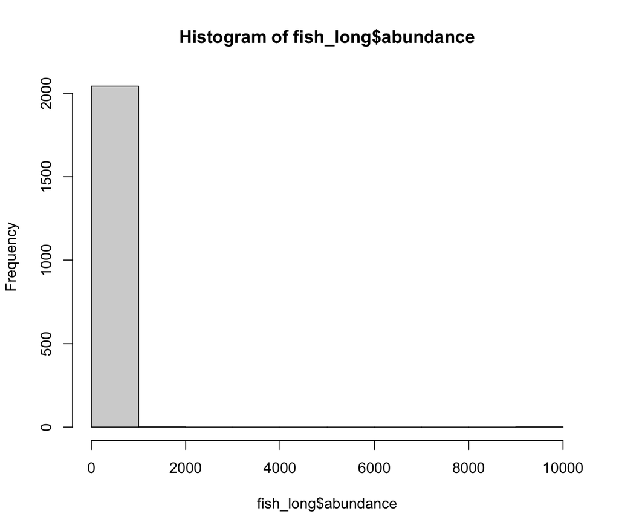

Figure 1: Histogram of fish abundance caught

in Figure 1 you can see that the catch data is heavily zero inflated. At many sites 0 fish of different species were caught. So lets try different transformations to shift the distribution of the data. A common approach is log transformations

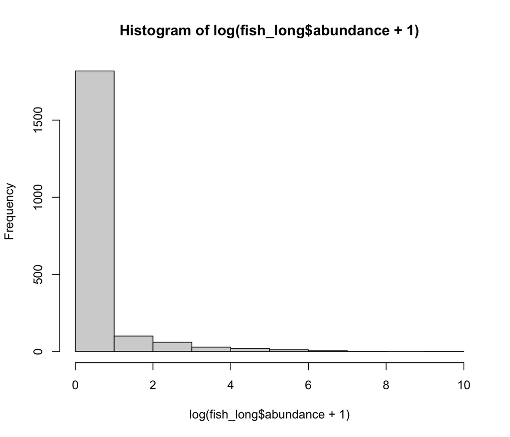

Figure 2: Histogram of log transformation of total fish caught

Lets try a 4th root transformation, another common transformation

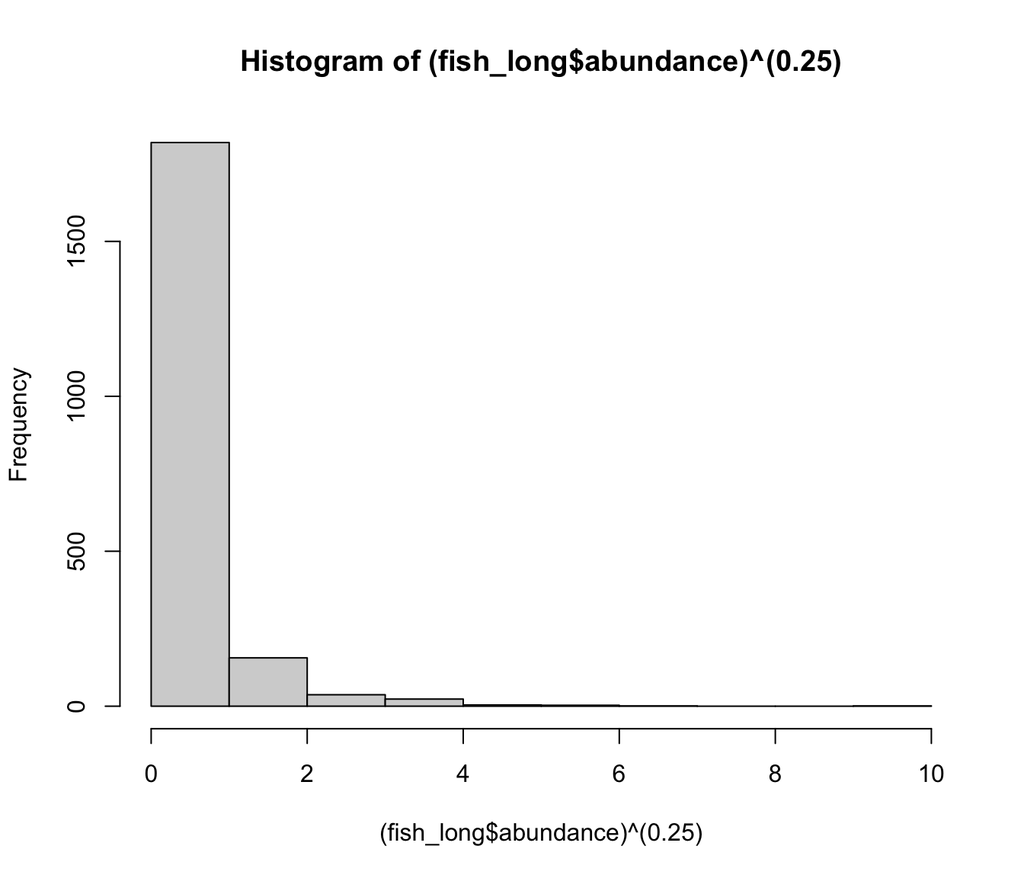

Figure 3 looks almost the same as a log transformation. Right now I’m using all the abundnaces summed together, what if we seperated by species.

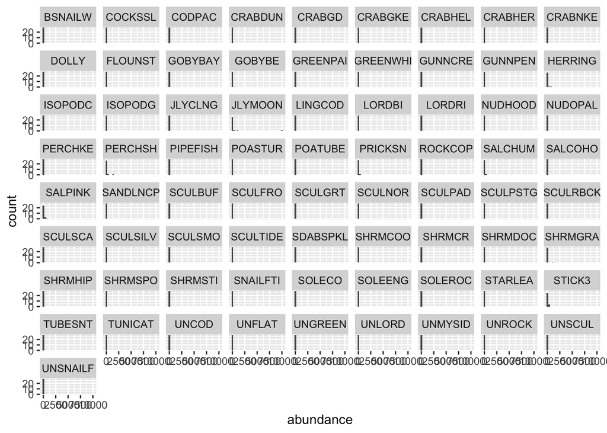

Figure 4: Histograms of fish abundances by species and site

In comparison with figure 1 the histogram by species in figure 4 is very similar. Lets look at it with log and 4th root transformations as well.

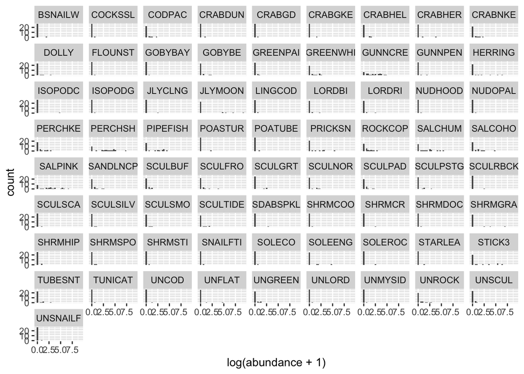

Figure 5: Histograms of log transformed fish abundances by species and site

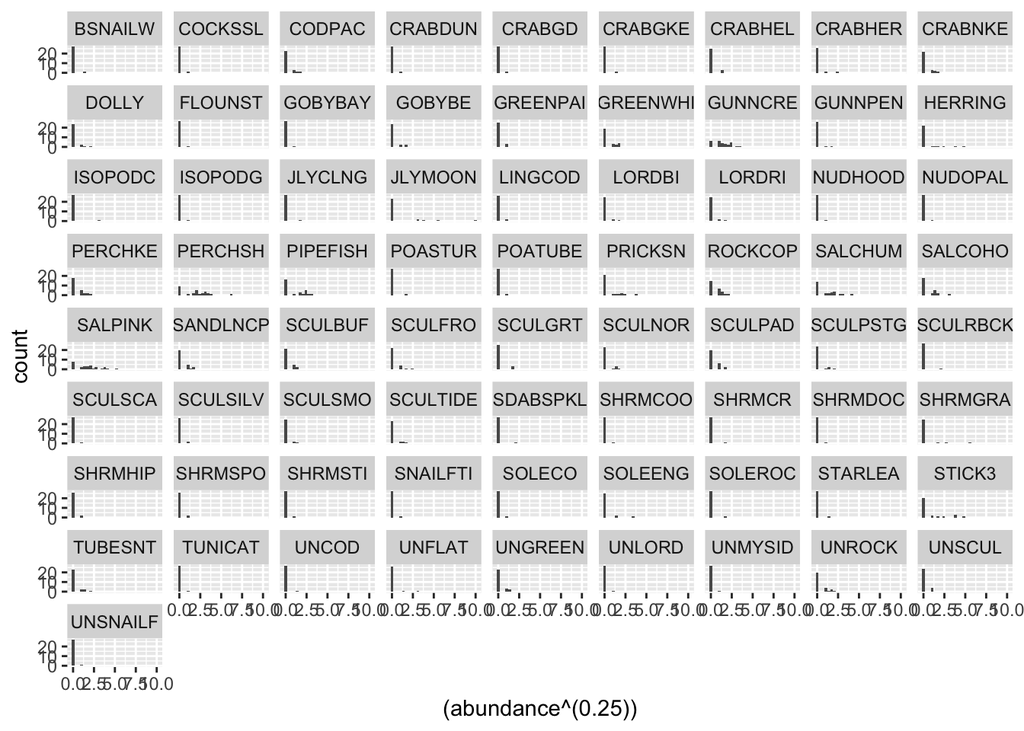

Figure 6: Histograms of fourth root transformed fish abundances by species and site

## Standardization seine

## Transformation env

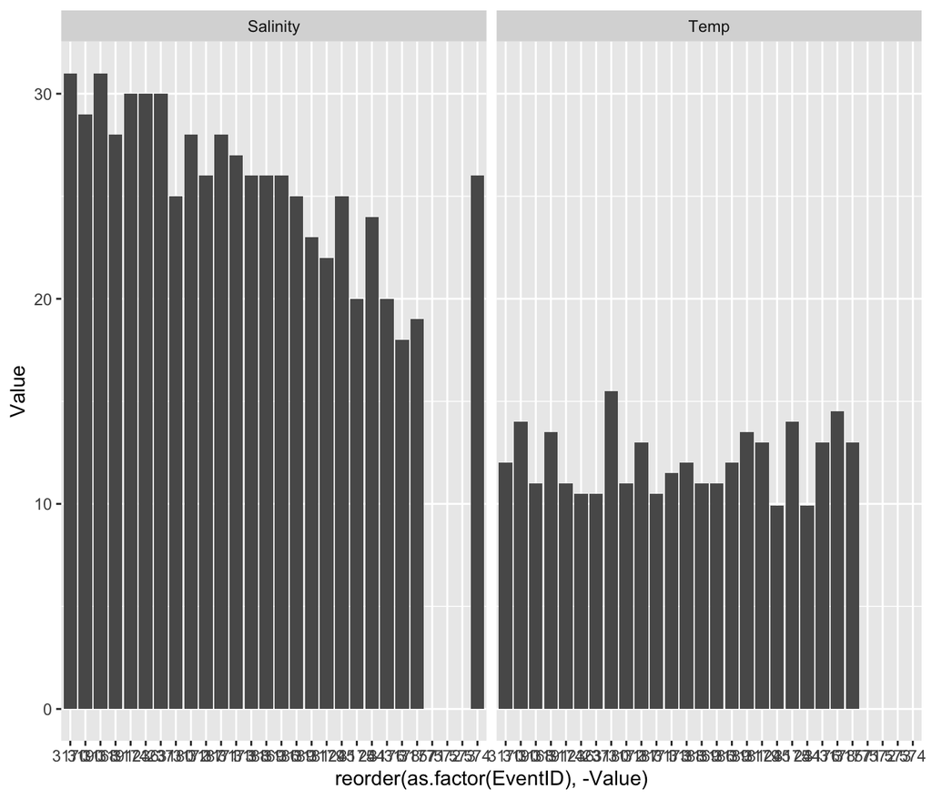

Figure 7: Bar graphs of salinity and temperature values from sites where seines took place

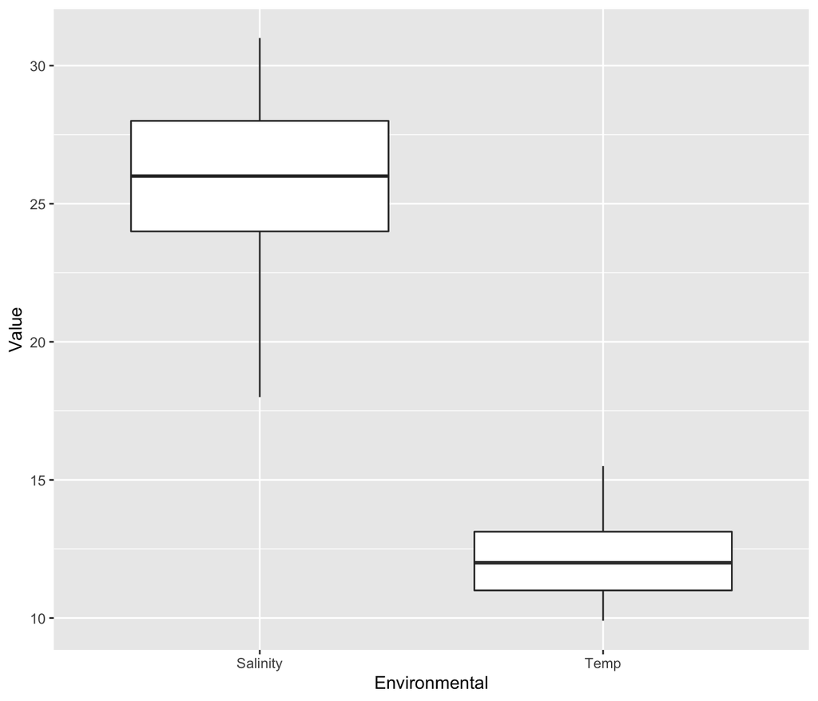

Figure 8: Boxplot of spread of environmental values

## Standardization env

# NMDS work

## Calculate dissimilarity index for both dataframes

## Dispersion test

## Calculate NMDS

## Create species biplot

## Overlay environmental parameters?

# Clean up NMDS plots